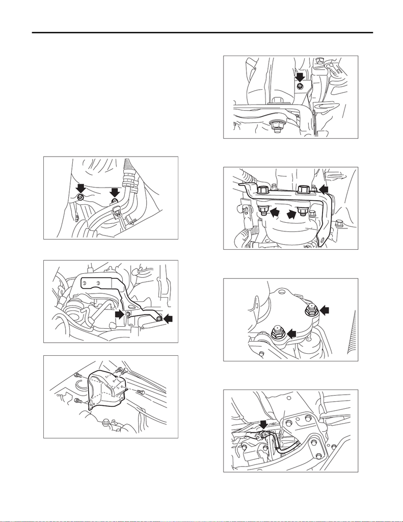

EX(STI)-7

Center Exhaust Pipe

EXHAUST

3. Center Exhaust Pipe

A: REMOVAL

CAUTION:

Vehicle components are extremely hot after

driving. Be wary of receiving burns from heated

parts.

1) Disconnect the ground cable from battery.

2) Remove the intercooler. <Ref. to IN(STI)-13,

REMOVAL, Intercooler.>

3) Lift up the vehicle.

4) Remove the transmission under cover.

5) Remove the bolts which secure the lower side of

the turbocharger lower cover.

6) Lower the vehicle.

7) Remove the intercooler stay RH No. 2.

8) Remove the turbocharger upper cover.

9) Remove the bolts which hold the upper side of

the turbocharger lower cover.

10) Remove the upper side bolts and nuts that hold

the center exhaust pipe on the turbocharger, and

remove the turbocharger cover stay (A).

11) Lift up the vehicle.

12) Remove the lower side nuts (two places) that

hold the center exhaust pipe on the turbocharger.

13) Disconnect the connector from the rear oxygen

sensor, and remove the clip (A) holding the rear ox-

ygen sensor harness.

EX-02255

EX-00007

EX-02662

EX-02762

EX-02464

(A)

EX-02339

EX-02331

(A)

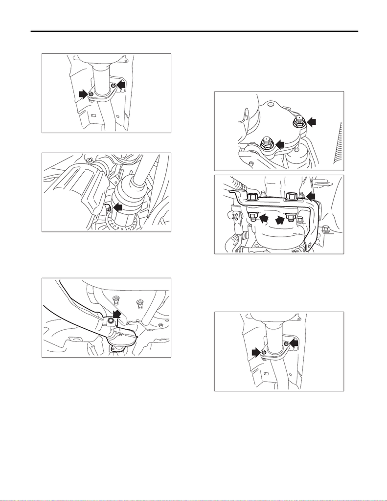

EX(STI)-8

Center Exhaust Pipe

EXHAUST

14) Remove the rear exhaust pipe from center ex-

haust pipe.

15) Remove the bolt which holds center exhaust

pipe to transmission.

16) Remove the bolt which holds center exhaust

pipe to hanger bracket, and remove the center ex-

haust pipe.

CAUTION:

Be careful not to drop the center exhaust pipe.

17) Remove the turbocharger lower cover.

B: INSTALLATION

1) Set the turbocharger lower cover, and temporari-

ly tighten the bolts that hold the lower side of the

turbocharger lower cover.

2) Install the center exhaust pipe and temporarily

tighten the bolt which holds center exhaust pipe to

hanger bracket.

3) Temporarily tighten the bolt which holds the cen-

ter exhaust pipe to the transmission.

4) Install the center exhaust pipe along with the tur-

bocharger cover stay (A) to the turbocharger.

NOTE:

Use a new gasket.

Tightening torque:

42.5 N·m (4.3 kgf-m, 31.3 ft-lb)

5) Install the rear exhaust pipe to center exhaust

pipe.

NOTE:

Use a new gasket.

Tightening torque:

18 N·m (1.8 kgf-m, 13.3 ft-lb)

EX-03136

EX-02182

EX-03145

EX-02339

EX-02464

(A)

EX-03136

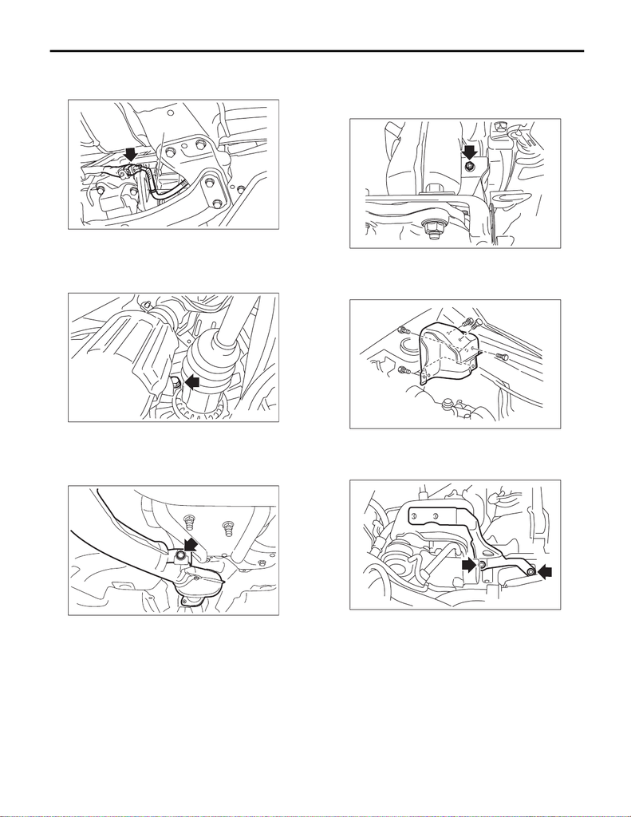

EX(STI)-9

Center Exhaust Pipe

EXHAUST

6) Connect the connector to the rear oxygen sen-

sor, and hold the rear oxygen sensor harness with

the clip (A).

7) Tighten the bolt which holds center exhaust pipe

to transmission.

Tightening torque:

30 N·m (3.1 kgf-m, 22.1 ft-lb)

8) Tighten the bolts which secure the center ex-

haust pipe to the hanger bracket.

Tightening torque:

35 N·m (3.6 kgf-m, 25.8 ft-lb)

9) Lower the vehicle.

10) Attach the bolt which holds the upper side of

the turbocharger lower cover.

Tightening torque:

7.5 N·m (0.8 kgf-m, 5.5 ft-lb)

11) Attach the turbocharger upper cover.

Tightening torque:

7.5 N·m (0.8 kgf-m, 5.5 ft-lb)

12) Install the intercooler stay RH No. 2.

Tightening torque:

16 N·m (1.6 kgf-m, 11.8 ft-lb)

13) Lift up the vehicle.

EX-02331

(A)

EX-02182

EX-03145

EX-02762

EX-02662

EX-00007

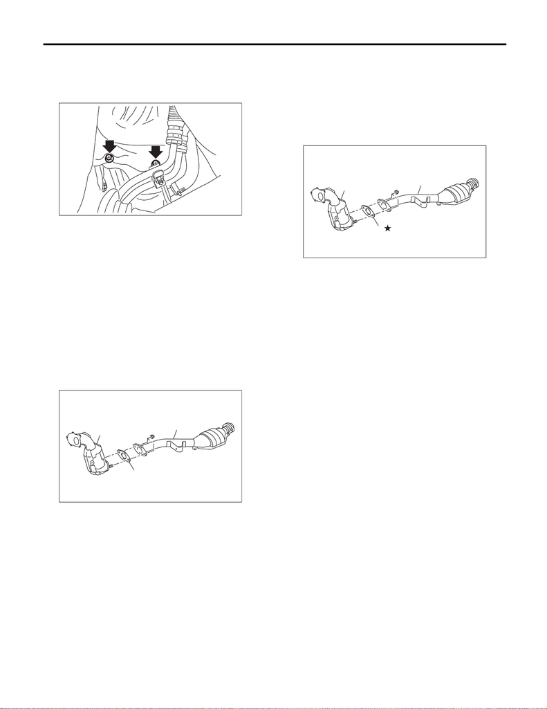

EX(STI)-10

Center Exhaust Pipe

EXHAUST

14) Tighten the bolts that secure the lower side of

the turbocharger lower cover.

Tightening torque:

7.5 N·m (0.8 kgf-m, 5.5 ft-lb)

15) Install the transmission under cover.

Tightening torque:

18 N·m (1.8 kgf-m, 13.3 ft-lb)

16) Lower the vehicle.

17) Install the intercooler. <Ref. to IN(STI)-14, IN-

STALLATION, Intercooler.>

18) Connect the battery ground terminal.

C: DISASSEMBLY

1) Remove the rear oxygen sensor from the center

exhaust pipe (rear). <Ref. to FU(STI)-54, REMOV-

AL, Rear Oxygen Sensor.>

2) Remove the center exhaust pipe upper cover.

3) Remove the center exhaust pipe (rear) from the

center exhaust pipe (front).

D: ASSEMBLY

1) Assemble the center exhaust pipe (rear) to the

center exhaust pipe (front).

NOTE:

Use a new gasket.

Tightening torque:

42.5 N·m (4.3 kgf-m, 31.3 ft-lb)

2) Install the center exhaust pipe upper cover.

Tightening torque:

13 N·m (1.3 kgf-m, 9.6 ft-lb)

3) Install the rear oxygen sensor to the center ex-

haust pipe (rear). <Ref. to FU(STI)-54, INSTALLA-

TION, Rear Oxygen Sensor.>

E: INSPECTION

1) Check the connections and welds for exhaust

leaks.

2) Make sure there are no holes or rusting.

(A) Center exhaust pipe (front)

(B) Center exhaust pipe (rear)

(C) Gasket

EX-02255

EX-02741

(C)

(B)

(A)

(A) Center exhaust pipe (front)

(B) Center exhaust pipe (rear)

(C) Gasket

EX-02742

(C)

(B)

(A)